# kNN

It is a lazy learning algorithm. Lazy learning doesn't have a training stage.

Operates on an entire dataset and identifies the class of one (or more and each) query.

Operates on distances from a query to every point from the availabe dataset.

Could be evaluated by splitting the entire dataset into train/test data. Each test query is run agains the entire train dataset. Then the accuracy of prediction is checked.

#### Import used libraries

```python
import numpy as np # for data
from matplotlib import pyplot as plt # for visualization
import math # for square root
from sklearn.preprocessing import LabelEncoder # for labeling data
from scipy.stats import mode # for voting
```

#### Plot functions

I've splitted the plotting functionality into 3 functions: dataset, neighbors and a query.

```python
plt.style.use('seaborn-whitegrid')

def plot_dataset(f, l):

    # Females
    x0 = f[l == 0, 0]
    y0 = f[l == 0, 1]
    plt.plot(x0, y0, 'ob', label='all Females')

    # Males
    x1 = f[l == 1, 0]
    y1 = f[l == 1, 1]
    plt.plot(x1, y1, 'or', label='all Males')

def plot_neighbors(f, l):

    x = f[:, 0]
    y = f[:, 1]
    k = len(f)

    plt.plot(x, y, 'oy', label=f'{k} neighbors')

def plot_query(q, p):

    x = q[0]
    y = q[1]

    label = 'Male' if p[0] == 1 else 'Female'

    plt.plot(x, y, 'sg', label=f'It\'s a {label}')

    print(f'Height: {x}')
    print(f'Wight: {y}')
    print(f'Class: {label}')
```

#### Load data

This section is about importing necessary data into out program.

Could be done from a file, from a library (iris dataset) and any other source.

##### Current dataset |sex|height|weight|: https://www.kaggle.com/mustafaali96/weight-height

```python
def load_data():
    raw_data = []
    #     with open('500_Person_Gender_Height_Weight_Index.csv', 'r') as file:
    with open('weight-height.csv', 'r') as file:

        # Discard the first line (headings)
        next(file)

        # Read the data into a table
        for line in file.readlines():
            data_row = line.strip().split(',')
            raw_data.append(data_row)

    return np.array(raw_data)
```

#### Meterics

- Sum of Absolute Difference (SAD)
- Sum of Squared Difference (SSD)
- Mean-Absolute Error (MAE)
- Mean-Squared Error (MSE)
- Euclidean Distance
- Manhattan Distance
- Chebyshev Distance
- Minkowski Distance
- Canberra Distance
- Cosine Distance
- Pearson's Distance
- Hamming Distance

```python
def euclidean_distance(point1, point2):
    sum_squared_distance = 0

    for i in range(len(point1)):
        sum_squared_distance += math.pow(point1[i] - point2[i], 2)
    return math.sqrt(sum_squared_distance)

def manhattan_distance(point1, point2):
    pass
```

#### Preprocess data

Data preprocessing simply means data formatting (e.g. '2.7' to 2.7), filling out or removing rows with missing data (N/A), scaling large numbers down, encoding ctegorical data (e.g. ['Male', 'Female'] to [2, 1]), splitting train/test.

```python
def preprocess(raw_data):
    le = LabelEncoder()
    label_rows = []

    features = []
    labels = []


    for row in raw_data:
        feature_row = list(map(float, row[1:3]))

        # select feature data
#         label = row[0][1:-1]
        label = row[0]

        features.append(feature_row)
        label_rows.append(label)

    # transform categorical data (labels)
    labels = le.fit_transform(label_rows)

    return np.array(features), np.array(labels)
```

#### k-Nearest Neighbors algorithm

Finding k closest neighbors and then voting for the class. k is preferred to be odd.

[figure not shown]

```python
def knn(features, labels, query, k, distance_fn):

    all_neighbors = []

    for index, sample in enumerate(features):
        # 1
        distance = distance_fn(sample, query)
        all_neighbors.append( (distance, index) ) # it's a tuple!

    # 2
    sorted_all_neighbors = sorted(all_neighbors)

    # 3
    k_neighbor_distances = sorted_all_neighbors[:k]
#     print(np.array([labels[index] for _, index in k_neighbor_distances]))

    # 4
    k_labels = np.array([labels[index] for _, index in k_neighbor_distances])
    k_neighbors = np.array([features[index] for _, index in k_neighbor_distances])

    return k_neighbors, k_labels, mode(k_labels) # mode == voting for the class
```

#### Run the code

Putting it all together

```python
def main():

    data = load_data() # how many columns? what are they?
    plt.xlabel('height [inches]')
    plt.ylabel('weight [pounds]')
    k = 5


    features, labels = preprocess(data) # how do we split features/labels? what are we doing with N/A or '2,1'?
    plot_dataset(f=features, l=labels)


    query = np.array(
        [70,  175]
    ) # what if it's a 2D array with rows as queries?

    k_neighbors, k_classes, predicted_class = knn(features,
                                                  labels,
                                                  query=query,
                                                  k=k,
                                                  distance_fn=euclidean_distance) # distance


    plot_neighbors(f=k_neighbors, l=k_classes)
    plot_query(q=query, p=predicted_class)

    plt.legend()
    plt.show()
```

```
Height: 70
Wight: 175
Class: Male
```

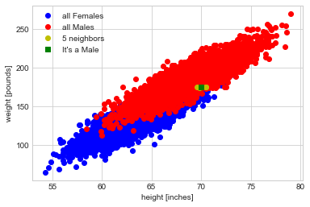

```python
main()
```